# Bolsos de lujo de segunda mano: una muestra estratificada y un experimento sobre el diseño muestral

Modalidad conjunta: Diseño de Experimentos + Muestreo Estadístico · Corte III · Universidad El Bosque

Karol Ximena Salcedo Ponguta y Mariana Lizarazo Buitrago

Noviembre de 2026

# 1 Resumen

Estudiamos los anuncios de bolsos de Louis Vuitton, Chanel y Hermès en Vestiaire Collective a partir de un archivo público de 11.988 anuncios.

- **Muestreo.** Con una muestra estratificada por marca de 150 anuncios, estimamos un precio medio de reventa de **£4.023** (IC 95 %: £3.612 a £4.435). El 46,6 % de los anuncios está agotado, y un bolso se revende en promedio al 87 % de su precio en tienda.
- **Experimento.** En un factorial 2 × 2 con las marcas como bloques y 240 corridas, comparamos dos decisiones de diseño muestral. Pasar de 30 a 90 anuncios bajó el error relativo de la media de 9,1 % a 6,5 %. Estratificar dentro de cada marca por estado de conservación lo bajó en apenas 1,27 puntos porcentuales.
- **Conclusión.** La marca separa mucho el precio y estratificar por ella rinde. El estado de conservación separa poco y estratificar por él casi no rinde.

# 2 La pregunta, la población y el marco

**Pregunta de Muestreo (Parte A).** ¿Cuál es el precio medio de reventa de los bolsos de Louis Vuitton, Chanel y Hermès anunciados en Vestiaire Collective, qué proporción de los anuncios aparece agotada y qué parte de su precio en tienda conservan, y cómo varía esto entre las tres marcas?

**Pregunta de Diseño (Parte B).** Dentro de cada marca, ¿cuánto mejora la estimación del precio medio si se estratifica por estado de conservación, y cuánto si se triplica el tamaño de muestra?

**Población objetivo.** Los anuncios de bolsos de segunda mano de esas tres marcas publicados en Vestiaire Collective cuando se recogió el archivo, cuya versión publicada es de mayo de 2021. No es el mercado de hoy ni el de otras plataformas.

**Marco.** El archivo público `Part_2/preview.csv` del repositorio Ketevana/Data-Science-Capstone-Project, en la versión `b567eb7`. Tiene 12.916 anuncios obtenidos por web scraping. `R/00-marco.R` lo depura y deja 11.988 anuncios, cada uno con un identificador y su estrato:

Construcción del marco.

| Paso | Anuncios |
| --- | --- |
| Archivo original | 12.916 |
| Sin marca | 12.308 |
| Sin duplicados | 11.990 |
| Sin estado «Vintage» | 11.988 |

**Cobertura.** Quedan fuera dos grupos:

- 608 anuncios sin marca, que no se pueden asignar a un estrato;
- los anuncios que el scraping no recogió, cuyo número no conocemos.

Si esos anuncios son de modelos menos buscados y más baratos, el marco sobrerrepresenta los bolsos caros y el precio medio queda **sobreestimado** frente a la población objetivo. Los duplicados y los dos anuncios «Vintage» no cambian la población: los primeros se cuentan una sola vez y los segundos son casos aislados.

# 3 Parte A · La muestra concreta (Muestreo)

## 3.1 El diseño y por qué ese

**Diseño.** Muestreo estratificado por marca, con muestreo aleatorio simple sin reemplazo dentro de cada estrato y asignación de Neyman ($n_h \propto N_h S_h$). La marca está en el marco y separa mucho el precio, así que estratificar por ella quita de la varianza la diferencia entre marcas. La de Neyman pone más muestra donde el precio varía más.

**Comparación con las alternativas.** El margen esperado al 95 % del precio medio con $n = 150$ es:

$$e = z\sqrt{\sum_h W_h^2
\left(1-\tfrac{n_h}{N_h}\right)\frac{S_h^2}{n_h}}$$

y, con aleatorio simple, $z\sqrt{(1 - n/N)S^2/n}$. Se calculó con las desviaciones del piloto, que fue lo único que conocíamos al escribir el protocolo. Como el marco es el archivo completo, abajo se recalcula también con las desviaciones reales:

Margen de error esperado al 95 % para el precio medio, con n = 150.

| Diseño | Margen con el piloto (£) | Margen con las S reales (£) |
| --- | --- | --- |
| Aleatorio simple | 580 | 1.014 |
| Estratificado proporcional | 279 | 761 |
| Estratificado de Neyman (34/89/27) | 213 | 518 |

Con el piloto, el estratificado de Neyman prometía un margen casi tres veces menor que el aleatorio simple, y por eso se eligió. Con las desviaciones reales la ventaja se mantiene: £518 frente a £1.014. Esa es la ganancia de estratificar.

Lo que no se cumplió fue el nivel: el piloto subestimó la desviación del precio en las tres marcas, sobre todo en Hermès (3.298 frente a 9.487 real). Con las desviaciones reales, la asignación de Neyman óptima habría sido de 21 / 110 / 20 anuncios. Es decir, aún más muestra en Hermès. Diez anuncios por estrato no bastan para estimar bien una desviación cuando hay pocos bolsos muy caros (pieles exóticas, ediciones limitadas). Con un piloto más grande habríamos elegido un tamaño mayor.

## 3.2 Probabilidades de inclusión, selección y comprobación

Cada anuncio $k$ del estrato $h$ entra con probabilidad $\pi_k = n_h/N_h$ y su peso es $w_k = 1/\pi_k$:

Probabilidades de inclusión y pesos.

| Estrato | N_h | n_h | pi_k | Peso |
| --- | --- | --- | --- | --- |
| Chanel | 3.576 | 34 | 0,00951 | 105,18 |
| Hermès | 2.920 | 89 | 0,03048 | 32,81 |
| Louis Vuitton | 5.492 | 27 | 0,00492 | 203,41 |

`R/seleccion.R` ordena los anuncios de cada estrato por un número uniforme aleatorio y toma los primeros $n_h$, con la semilla 20261113. Lo escribe en `datos/muestra.csv`, donde los pesos suman 11.988. Para comprobar el guion, se repitió la selección 2.000 veces y se contó cuántas veces salió cada anuncio:

Frecuencia de selección en 2.000 repeticiones.

| Estrato | pi_k del protocolo | Frecuencia media |
| --- | --- | --- |
| Chanel | 0,00951 | 0,00951 |
| Hermès | 0,03048 | 0,03048 |
| Louis Vuitton | 0,00492 | 0,00492 |

24 de los 11.988 anuncios (0,20 %) se alejan de su $\pi_k$ más de tres errores estándar de Monte Carlo. Por azar se esperaría alrededor del 0,3 %. Ningún anuncio salió en todas las repeticiones (0). Los que no salieron en ninguna fueron 1, una cantidad compatible con el azar en Louis Vuitton, donde $\pi_k$ es la más pequeña. El guion sortea con las probabilidades del protocolo.

## 3.3 Datos y no respuesta

El marco es un archivo público: no hubo contacto con personas. El «campo» fue tomar del archivo los datos de cada anuncio seleccionado (`R/datos.R`). El precio de reventa y el estado de agotado están completos. El precio en tienda falta en algunos anuncios: esa es la no respuesta.

Tasa de respuesta por estrato.

| Estrato | Seleccionados | Respondieron | Tasa |
| --- | --- | --- | --- |
| Chanel | 34 | 34 | 100,0 % |
| Hermès | 89 | 89 | 100,0 % |
| Louis Vuitton | 27 | 25 | 92,6 % |
| Total | 150 | 148 | 98,7 % |

Los dos anuncios sin precio en tienda son de Louis Vuitton (A02223 y A02500). No se sustituyeron por otros. Entran en la estimación del precio y de la proporción de agotados, y solo se excluyen de la razón entre precios. Para la razón, los pesos de los respondientes se ajustan dentro de cada estrato: $w_k^{aj} = w_k / \hat r_h$, donde $\hat r_h$ es la tasa de respuesta del estrato. El supuesto es que, dentro de cada marca, que falte el precio en tienda no depende de cuánto valor conserva el bolso.

## 3.4 Estimación

Todas las estimaciones usan el diseño declarado en `survey`, con estratos, pesos y corrección por población finita (`R/estimacion.R`).

Estimaciones para la población del marco.

| Parámetro | Estimación | Error estándar | IC 95 % | Efecto de diseño |
| --- | --- | --- | --- | --- |
| Precio medio de reventa (£) | 4.023 | 210 | 3.612 a 4.435 | 0,18 |
| Proporción de anuncios agotados | 46,6 % | 5,1 % | 36,7 % a 56,6 % | 1,56 |
| Razón reventa / tienda | 0,87 | 0,03 | 0,81 a 0,93 | — |

Estimaciones por marca, con su IC 95 % entre paréntesis.

| Marca | Precio medio (£) | % agotado | Razón reventa / tienda |
| --- | --- | --- | --- |
| Chanel | 2.843 (2.472 a 3.215) | 29,4 % (13,9 % a 44,9 %) | 0,87 (0,77 a 0,97) |
| Hermès | 11.877 (10.264 a 13.490) | 37,1 % (27,1 % a 47,0 %) | 1,34 (1,23 a 1,46) |
| Louis Vuitton | 616 (501 a 730) | 63,0 % (44,4 % a 81,5 %) | 0,62 (0,52 a 0,72) |

**Verificación por otra vía.** El estimador estratificado y su varianza se calcularon también con la fórmula, sin `survey`:

$$\bar y_{st} = \sum_h W_h \bar y_h,
\qquad \hat V(\bar y_{st}) = \sum_h W_h^2\left(1 -
\frac{n_h}{N_h}\right)\frac{s_h^2}{n_h}$$

Mismo resultado por dos vías.

| Parámetro | survey: estimación | Fórmula: estimación | survey: error estándar | Fórmula: error estándar |
| --- | --- | --- | --- | --- |
| Precio medio (£) | 4.023,18 | 4.023,18 | 209,96 | 209,96 |
| Proporción agotada | 0,46650 | 0,46650 | 0,05080 | 0,05080 |

Las dos vías coinciden.

## 3.6 Comprobación contra el valor real

Como el marco es el archivo completo, el parámetro se conoce y se puede ver si cada intervalo lo contiene:

Intervalos frente al valor real del marco.

| Parámetro | Valor real | ¿El IC lo contiene? |
| --- | --- | --- |
| Precio medio (£) | 4.044 | Sí |
| Precio medio, Chanel | 2.880 | Sí |
| Precio medio, Hermès | 11.325 | Sí |
| Precio medio, Louis Vuitton | 930 | **No** |
| Proporción agotada | 44,8 % | Sí |
| Agotados, Chanel | 35,7 % | Sí |
| Agotados, Hermès | 35,0 % | Sí |
| Agotados, Louis Vuitton | 56,1 % | Sí |
| Razón reventa / tienda | 0,91 | Sí |
| Razón, Chanel | 0,83 | Sí |
| Razón, Hermès | 1,28 | Sí |
| Razón, Louis Vuitton | 0,77 | **No** |

Los intervalos generales contienen el valor real. Los de precio y razón de Louis Vuitton no. Para saber si eso es mala suerte o algo del diseño, se simularon 1.000 muestras con el mismo diseño y se contó cuántas veces el intervalo contiene el valor real:

Porcentaje de 1.000 muestras en que el IC 95 % contiene el valor real.

| Intervalo | Cobertura simulada |
| --- | --- |
| Precio medio total | 91,4 % |
| Precio medio, Chanel | 93,4 % |
| Precio medio, Hermès | 89,5 % |
| Precio medio, Louis Vuitton | 86,6 % |

Los intervalos cubren menos del 95 % que prometen, y lo peor es Louis Vuitton (86,6 %). La causa es la asimetría del precio. En Louis Vuitton, la mayoría de los bolsos vale entre £490 y £1.040, pero unos pocos modelos (Capucines y algunas ediciones especiales) superan los £10.000. Con 27 anuncios, lo más probable es que la muestra no incluya ninguno de esos bolsos caros. Entonces la media sale baja y la desviación también, y el intervalo queda corto y desplazado hacia abajo. Eso fue lo que pasó en nuestra muestra.

# 4 Parte B · El experimento sobre el diseño muestral (Diseño de Experimentos)

## 4.1 La pregunta y lo que se midió

En la Parte A, estratificar por marca redujo mucho la varianza. La pregunta del experimento es qué más se puede ganar **dentro** de una marca. ¿Cuánto mejora la estimación del precio medio si se estratifica por estado de conservación en vez de usar un aleatorio simple, y cuánto si se pasa de 30 a 90 anuncios? ¿Depende lo primero de lo segundo? La respuesta importa para planear la próxima muestra: ¿conviene invertir en un marco con el estado de cada anuncio, o en más anuncios?

- **Respuesta:** el error relativo absoluto de la estimación del precio medio, $100\,|\hat{\bar y}-\bar Y|/\bar Y$, en %. Es exacto porque se conoce la media real de cada población.
- **Unidad experimental y de observación:** la corrida, es decir, una muestra nueva, con su propia semilla, de la población de una marca, que da una estimación.

## 4.2 El diseño, planeado y corrido

El diseño es un factorial 2 × 2 en bloques completos al azar:

- **Diseño muestral:** aleatorio simple, o estratificado por estado de conservación en tres grupos, con asignación proporcional.
- **Tamaño:** 30 o 90 anuncios.
- **Bloques:** las poblaciones de Chanel, Hermès y Louis Vuitton.
- **Réplicas:** 20 réplicas por celda y bloque, es decir, 240 corridas. Cada réplica es una muestra nueva, no una submuestra de la misma.

`R/tabla-corridas.R` sorteó el orden de las corridas y la semilla de cada una, con la semilla 20261123 del preregistro. Las corridas se ejecutaron en ese orden (el orden real coincide con el planeado). No hubo corridas perdidas. Lo que se apartó del plan está en «Desviaciones».

Por qué este diseño y no uno más simple:

- Con un solo factor no se vería si la ganancia de estratificar cambia con el tamaño.
- Sin bloques, la diferencia entre marcas quedaría en el error. Los precios de Louis Vuitton y Hermès son más dispersos que los de Chanel, así que su error relativo es mayor por razones ajenas a los factores.

## 4.3 Análisis confirmatorio

El modelo preregistrado es `error ~ bloque + diseño * tamaño`, con el bloque como factor.

**Supuestos.** El error absoluto no puede ser negativo y tiene una cola larga, así que los residuos del modelo con la respuesta original se revisaron antes de leer la tabla:

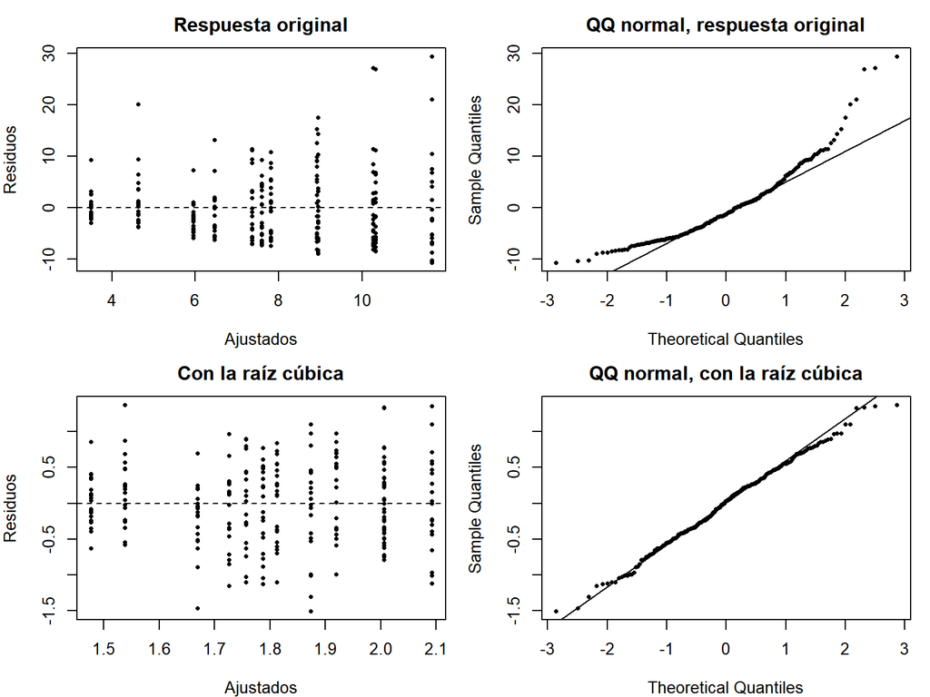

Con la respuesta original, los residuos son asimétricos hacia la derecha y su dispersión crece con el valor ajustado. El preregistro fijaba el remedio: Box-Cox. Dio $\lambda =$ 0,31, que se redondea a la potencia más cercana de las preregistradas (0, 1/3, 1/2 o 1), así que el análisis usa **la raíz cúbica** del error. Con esa transformación los residuos quedan aproximadamente simétricos y con dispersión más pareja (fila inferior de los gráficos). La tabla ANOVA con la respuesta transformada es:

ANOVA del error relativo, con la raíz cúbica.

| Fuente | gl | SC | CM | F | p |
| --- | --- | --- | --- | --- | --- |
| Bloque (marca) | 2 | 4,88 | 2,44 | 7,55 | 0,000663 |
| Diseño | 1 | 0,33 | 0,33 | 1,03 | 0,312 |
| Tamaño | 1 | 2,54 | 2,54 | 7,87 | 0,00544 |
| Diseño × Tamaño | 1 | 0,01 | 0,01 | 0,03 | 0,865 |
| Error | 234 | 75,53 | 0,32 |  |  |

- **Interacción.** La interacción diseño × tamaño no es significativa (p = 0,87). Por eso se pueden leer los efectos principales por separado.
- **Tamaño.** El efecto del tamaño es significativo (p = 0,0054).
- **Diseño.** El efecto del diseño no es significativo (p = 0,31).
- **Bloque.** El bloque es significativo: el error relativo cambia de una marca a otra, y meterlo en el modelo le quitó esa variación al error.

**Tamaño de los efectos, en la escala original.** Las diferencias se estiman con el método de Tukey sobre el modelo con la respuesta original. Con 120 corridas por nivel, las medias son estables aunque los residuos sean asimétricos.

Error relativo por tratamiento (las tres marcas juntas).

| Diseño | Tamaño | Error medio (%) | Error mediano (%) |
| --- | --- | --- | --- |
| Aleatorio simple | 30 | 9,78 | 6,60 |
| Estratificado por estado | 30 | 8,37 | 5,81 |
| Aleatorio simple | 90 | 7,05 | 5,67 |
| Estratificado por estado | 90 | 5,92 | 4,79 |

- **Tamaño.** Al pasar de 30 a 90 anuncios, el error relativo medio cambia en -2,59 puntos porcentuales (IC 95 %: -4,29 a -0,89). El error con 30 anuncios es 1,40 veces el de 90. La teoría predice unas $\sqrt{3}\approx 1{,}73$ veces, porque el error estándar cae con $1/\sqrt{n}$.
- **Diseño.** La diferencia en el error medio entre estratificar por estado y el aleatorio simple es de -1,27 puntos porcentuales (IC 95 %: -2,97 a 0,43). El intervalo incluye el cero: con estas réplicas no se puede descartar que estratificar por estado no cambie nada. Es una diferencia menor que la del tamaño. Coincide con lo que se esperaba: el estado de conservación explica poco del precio dentro de cada marca. Lo que más explica el precio es el modelo del bolso.

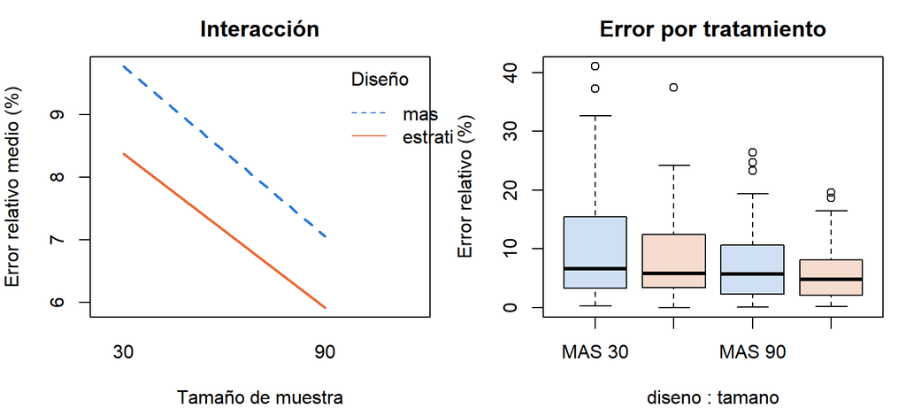

## 4.4 Conclusión del experimento

Para estimar el precio medio de reventa dentro de una marca, **el tamaño de muestra importa mucho más que estratificar por estado de conservación**. Triplicar el tamaño reduce el error relativo de forma clara, aunque menos de lo que predice la teoría (1,40 veces frente a 1,73). Una explicación probable es la cola larga de precios: con 30 anuncios casi nunca sale un bolso muy caro, y el error de esas muestras queda más concentrado de lo que supone la fórmula. Estratificar por estado reduce poco la varianza, porque el estado explica poco del precio dentro de cada marca. Si hubiera que elegir, conviene invertir en más anuncios o en estratificar por una variable que explique más el precio, como el modelo del bolso, y no en registrar el estado.

Lo que el experimento **no** permite concluir:

- Los resultados valen para estas tres poblaciones, con estos dos tamaños y este diseño estratificado; no para otras marcas ni para tamaños fuera de 30–90.
- La respuesta es el error de la media. Para la proporción de agotados u otros parámetros el resultado podría ser distinto.

# 5 Integración de las dos partes

**Qué da cada aleatorización y qué no.**

- **La selección aleatoria de la muestra concreta** (Parte A) da a cada anuncio una probabilidad de inclusión conocida, $\pi_k = n_h/N_h$. Eso permite pasar de la muestra al marco con pesos y medir la incertidumbre con el error estándar. No permite hablar de causas: describe la población.
- **La aleatorización del experimento** (Parte B) tiene dos partes. El orden de las corridas se sortea, aunque en un computador el orden no introduce deriva. Lo esencial es que cada corrida toma una muestra nueva con su propia semilla. Así, la única diferencia sistemática entre tratamientos es el diseño y el tamaño que se les asignó, y se puede atribuir a ellos la diferencia en el error. No permite generalizar fuera de las tres poblaciones usadas como bloques.

**A qué población se generaliza el efecto.** A las tres poblaciones de anuncios del marco: Chanel, Hermès y Louis Vuitton en el archivo de 2021. Los bloques son fijos (las tres marcas que hay), no una muestra de marcas, así que el efecto no se extiende a otras marcas ni al mercado actual.

**Cómo entra el diseño muestral en el análisis del experimento.**

- **Los estratos de la muestra concreta son los bloques del experimento.** La marca, que en la Parte A separaba el precio, en la Parte B se controla como bloque.
- **Cada corrida estima con el estimador correcto para su diseño:** la media simple en el aleatorio simple, y en el estratificado la media ponderada por $N_h/N$, con los mismos pesos que en la Parte A.
- **La ANOVA del experimento no lleva pesos.** Sus unidades son corridas, no anuncios. Cada corrida es una repetición igual de importante del procedimiento, y no representa a una parte distinta de la población.

**Cuánto del error es muestral y cuánto experimental.**

- **En la muestra concreta** todo el error es muestral: el error estándar del precio medio es de £210.
- **En el experimento** la respuesta *es* el error muestral, y lo que la ANOVA llama «error experimental» es cuánto varía ese error de una muestra a otra con el mismo diseño. Con la respuesta original, el bloque explica el 6,6 % de la variación del error, el tamaño el 3,4 %, el diseño el 0,8 % y la interacción el 0,0 %. El resto, 89,1 %, es puro azar de muestreo.

Es decir, la mayor parte de la variación del error no depende de ninguna decisión de diseño. Es la suerte de la muestra que toca. Por eso hace falta reportar siempre el intervalo, y no solo la estimación.

# 6 Limitaciones

- **Qué no se puede concluir.** Las estimaciones valen para el marco: los anuncios de estas tres marcas que recogió el archivo de 2021. No describen el mercado actual, otras plataformas ni otras marcas. Tampoco dicen por qué un bolso vale más. Este estudio describe; no establece causas.
- **Cobertura.** Si los 608 anuncios sin marca y los que el scraping no recogió son más baratos que el promedio, el precio medio de la población objetivo es menor que nuestra estimación. No sabemos cuánto.
- **No respuesta.** Solo afecta a la razón y solo en Louis Vuitton (2 de 27). El ajuste supone que faltar el precio en tienda no depende de la razón. Si esos bolsos son modelos descontinuados o raros, que suelen conservar más valor, la razón de Louis Vuitton estaría algo subestimada.
- **Intervalos con cobertura menor a la nominal.** En las marcas con precios muy asimétricos, y sobre todo en Louis Vuitton, el intervalo al 95 % cubre bastante menos. Una muestra más grande en ese estrato, un intervalo para la media del logaritmo del precio o un intervalo bootstrap serían mejores opciones. Las presentamos como sugerencias, no como parte del análisis planeado.
- **El piloto.** Subestimó la variabilidad, así que el tamaño quedó corto para el margen de £250 que se buscaba. El margen obtenido para el precio medio fue de £412.
- **El experimento.** Los efectos valen para estas tres poblaciones y para tamaños entre 30 y 90. El factor de diseño comparó un solo esquema de estratificación (por estado, con asignación proporcional). Que este rinda poco no dice nada de estratificar por otra variable, como el modelo del bolso.

# 7 Desviaciones del plan

[output not shown]

# 8 Análisis exploratorio

*Esta sección no estaba en el plan del protocolo: es exploratoria.*

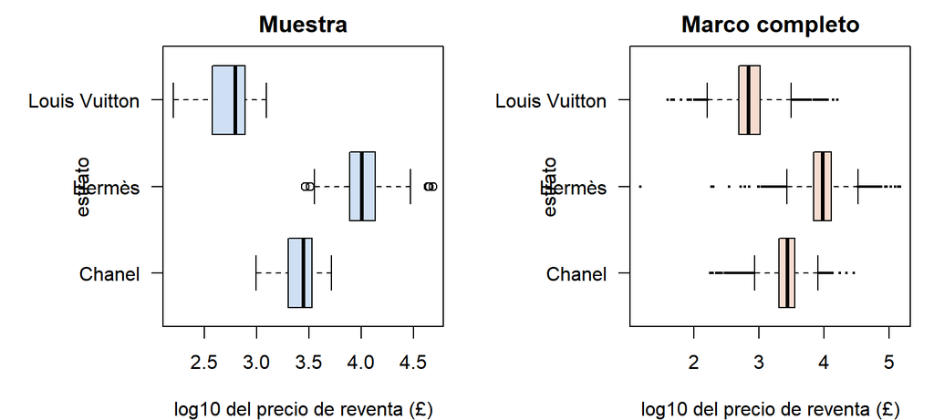

La muestra reproduce bien el centro de cada marca, pero en Louis Vuitton no capta la cola de bolsos caros que sí tiene el marco. Eso explica lo que se vio en la comprobación contra el valor real.

# 9 Declaración de uso de IA

Usamos **Claude** (Anthropic), un asistente conversacional, para:

- buscar una base pública que se pudiera submuestrear;
- escribir los guiones de R (marco, piloto, selección, comprobación, datos, tabla de corridas, experimento y estimación);
- hacer un piloto en simulación del experimento, que mostró residuos asimétricos y llevó a preregistrar la regla de Box-Cox;
- redactar el protocolo, el preregistro y este informe.

Lo que verificamos o corregimos nosotras:

1. **Las probabilidades de inclusión, anuncio por anuncio,** con `R/comprobacion.R` (ver «Probabilidades de inclusión, selección y comprobación»). Revisamos que la varianza use los estratos y la corrección por población finita, y no la de un aleatorio simple.
2. **Las estimaciones por dos vías,** con `survey` y con la fórmula.
3. **Que el modelo del experimento lleve el bloque como factor y que las réplicas sean muestras nuevas,** no submuestras. Es el error que la guía de Diseño advierte en los asistentes.
4. **Que la muestra de `datos/muestra.csv` sea la que escribe el guion** con la semilla 20261113: coincide con lo reportado en el avance.
5. **Las referencias bibliográficas,** en su fuente.

# 10 Referencias

- Ketevana. (2021). *Data-Science-Capstone-Project* [repositorio de GitHub]. https://github.com/Ketevana/Data-Science-Capstone-Project
- Lohr, S. L. (2021). *Sampling: Design and analysis* (3.ª ed.). Chapman and Hall/CRC.
- Lumley, T. (2004). Analysis of complex survey samples. *Journal of Statistical Software, 9*(8), 1–19. https://doi.org/10.18637/jss.v009.i08
- Montgomery, D. C. (2019). *Design and analysis of experiments* (10.ª ed.). Wiley.

# 11 Anexos

**Tabla de corridas del experimento.** Primeras 15 de las 240. El archivo completo está en `datos/tabla-corridas.csv` y los resultados de cada corrida en `datos/experimento.csv`.

| corrida | orden_planeado | bloque | diseno | tamano | replica | semilla_corrida |
| --- | --- | --- | --- | --- | --- | --- |
| C001 | 1 | HE | mas | 90 | 2 | 279374 |
| C002 | 2 | LV | mas | 90 | 8 | 297099 |
| C003 | 3 | LV | estratificado | 90 | 12 | 241765 |
| C004 | 4 | HE | estratificado | 30 | 9 | 241470 |
| C005 | 5 | HE | estratificado | 90 | 13 | 70545 |
| C006 | 6 | CH | estratificado | 30 | 2 | 82209 |
| C007 | 7 | CH | estratificado | 30 | 17 | 735671 |
| C008 | 8 | CH | mas | 30 | 16 | 60798 |
| C009 | 9 | CH | mas | 90 | 18 | 354062 |
| C010 | 10 | CH | estratificado | 30 | 5 | 49678 |
| C011 | 11 | CH | estratificado | 90 | 13 | 60644 |
| C012 | 12 | LV | estratificado | 30 | 6 | 916042 |
| C013 | 13 | HE | mas | 30 | 12 | 72191 |
| C014 | 14 | CH | mas | 30 | 14 | 390507 |
| C015 | 15 | LV | estratificado | 30 | 14 | 954425 |

**Bitácora.** Está en `datos/bitacora.md`.